# Visualizing City Migration Data with TidyCensus

Morgan Heinly

July 22, 2022

### Census flow data for Charlotte, NC

**Charlotte, NC** is said to be one of the fastest growing cities in the United States. Most sources report that over 100 people move to Charlotte every day - a sizable number when compared with its historic population. If sustained, these rapid migrations can have both desirable and undesirable consequences. An obvious example is the real estate market. Median mortgage and rent prices more than doubled over the past 10 years: a favorable phenomenon for longtime owners and real estate investors, but burdensome for restaurants, residential newcomers and tenants.

As an 8-year resident of Charlotte, I’ve also witnessed changes in other areas since I moved here in 2014, such as cultural shifts, growing demographic diversity, infrastructure expansion and more…

Understanding how all of these factors interact and transform a city can be a complex undertaking and one that’s way outside the scope of this analysis; but for starters, sometimes it can be helpful to narrow our focus to a single variable, pull some data, and explore through visualizations - a necessary step before any real statistical modeling can be done.

**Culture shifts** seem difficult to quantify, but for the sake of demonstration, it will be used for this example.

Since culture can generally be described by the collective characteristics of a group within a geographical area, then perhaps one approach could be analyzing areas or cities that new Charlotte residents are moving from. If there are unusual patterns or heavy move-in traffic out of cities with known cultural attributes, this could partly aide in describing Charlotte’s recent cultural evolution.

To showcase how this could be done, we’ll use the Tidycencus package to pull in data from 2015 to 2019 and look at which cities most people moved from over those years. *Note 2015 to 2019 is the latest 5 year estimates available for these data points.*

### Mapping moving-in / move out data

#### What were the top 25 origination cities for those **moving to** Charlotte during this time?

Use the interactive maps below to explore

[interactive chart not shown]

#### What were the top 25 destination cities for those **moving away** from Charlotte during this time?

Just for fun, we could also take a look at which cities Charlotte residents were moving to.

[interactive chart not shown]

### Observations

You can take the analysis in many different directions from here, but right off the bat, the maps provide some interesting information

- Most metro-movers come from the New York City area (more than double next highest city at 44K movers over the 5-year time period)
- Top cities are mostly from the North East and South East
- On average, top origin cities have higher numbers than destination, indicating net growth
- Roughly 4 times as many NYC residents moved to Charlotte than vice versa
- Raleigh, NC (another fast growing city) appears to be an outlier. More people moved from Charlotte to Raleigh vice-versa
- Charlotte residents who move away typically stay closer to the surrounding area, which could likely be the case for most cities in general

### What other things could be analyzed?

#### Potential newcomers

I was also curious about newcomers. In other words, which cities had no reported estimates or estimates of 0 from 2009 to 2013 (not shown here), that were included in the 2015 - 2019 estimates

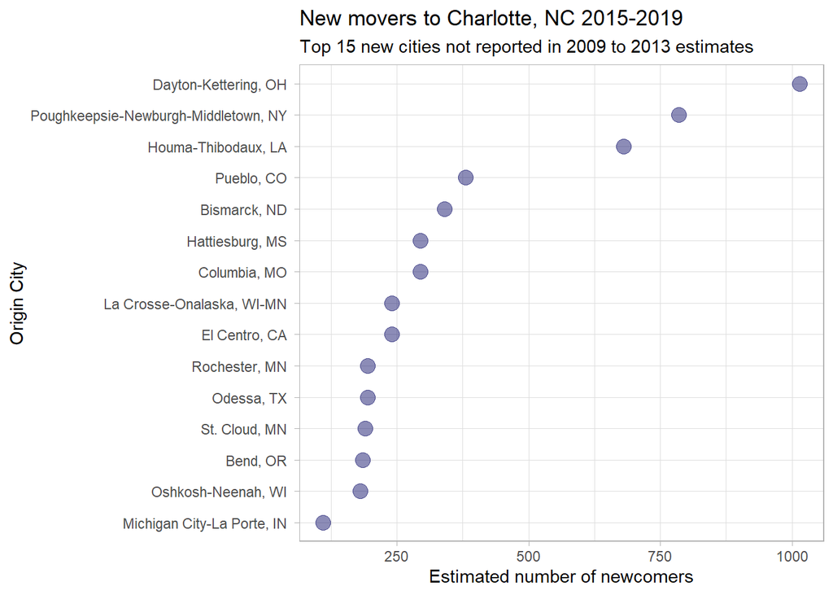

#### Growth rates

How about which cities with over 100 annual movers had the highest growth rates between the 2 periods?

|  | Origin_City | 2009 - 2013 Annual Est | 2015 - 2019 Annual Est | growth_rate |
| --- | --- | --- | --- | --- |
| 1 | Syracuse, NY | 157 | 669 | 326% |
| 2 | Jacksonville, NC | 131 | 473 | 261% |
| 3 | San Diego-Carlsbad, CA | 180 | 600 | 233% |
| 4 | Gainesville, FL | 188 | 626 | 233% |
| 5 | Minneapolis-St. Paul-Bloomington, MN-WI | 208 | 653 | 214% |
| 6 | Bridgeport-Stamford-Norwalk, CT | 219 | 671 | 206% |
| 7 | Rochester, NY | 403 | 1187 | 195% |
| 8 | Akron, OH | 206 | 592 | 187% |
| 9 | Indianapolis-Carmel-Anderson, IN | 216 | 591 | 174% |
| 10 | Lakeland-Winter Haven, FL | 135 | 348 | 158% |

[output cut: 50 more lines]

### Closing thoughts

In this exercise, there was no definitive conclusion or rigorous statistical analysis performed. However, we were able to quickly identify some descriptive info from a few charts and maps.

Using the Tidycencus package along with sleek visualization libraries such as Mapview and Mapdeck, analysts can access a wide array of U.S. Census data and use for exploratory analysis or even feature selection when performing more advanced modeling.